# NCDB-Lung

## 13.3 Interpretation

```r
summary(mortback)
```

```
Call:
glm(formula = PUF_VITAL_STATUS ~ Chemo + AGE_cat + SEX + RACE2 +
    SPANISH_ORIGIN2 + CROWFLY + CDCC_TOTAL_BEST + TUMOR_SIZE_cat +
    GRADE + Visceral_Pleural_Invasion + LYMPH_VASCULAR_INVASION2 +
    Margins + Lymph_Nodes_Sampled + Excision_less_than1, family = binomial(link = "logit"),
    data = (NCDB_lung2[, include_columns_mort]))

Deviance Residuals:
    Min       1Q   Median       3Q      Max
-2.7543   0.3734   0.4950   0.6165   1.3748

Coefficients:
                                   Estimate Std. Error z value Pr(>|z|)
(Intercept)                       3.7334717  0.5549882   6.727 1.73e-11 ***
ChemoNo Chemo                    -0.3222196  0.0850665  -3.788 0.000152 ***
AGE_cat60-70                     -0.2224953  0.0942198  -2.361 0.018204 *
AGE_cat70-80                     -0.5024050  0.0922823  -5.444 5.20e-08 ***
AGE_catAbove 80                  -0.8302481  0.1153215  -7.199 6.05e-13 ***
AGE_catBelow 50                   0.0971177  0.2560841   0.379 0.704509
SEXMale                          -0.5131052  0.0571949  -8.971  < 2e-16 ***
RACE2Other                        0.2863687  0.1850244   1.548 0.121686
RACE2Unknown                      0.7775166  0.4923824   1.579 0.114315
RACE2White                       -0.0822796  0.1040925  -0.790 0.429267
SPANISH_ORIGIN2Non-Hispanic      -0.2942138  0.1773264  -1.659 0.097083 .
SPANISH_ORIGIN2Unkown            -0.6486350  0.2695999  -2.406 0.016132 *
CROWFLY                           0.0004177  0.0003119   1.339 0.180426
CDCC_TOTAL_BEST                  -0.1698308  0.0277834  -6.113 9.80e-10 ***
TUMOR_SIZE_cat1cm-2cm            -0.8929984  0.3576572  -2.497 0.012532 *
TUMOR_SIZE_cat2cm-3cm            -0.8913434  0.3591102  -2.482 0.013061 *
TUMOR_SIZE_cat3cm-4cm            -1.1383881  0.3605204  -3.158 0.001591 **
TUMOR_SIZE_cat4cm-5cm            -1.3522088  0.3628594  -3.727 0.000194 ***
GRADEPoorly differentiated       -0.2522693  0.0627594  -4.020 5.83e-05 ***
GRADEUndifferentiated            -0.4136917  0.2277069  -1.817 0.069252 .
GRADEUnknown                      0.1540102  0.1056032   1.458 0.144734
GRADEWell differentiated          0.6255185  0.1149864   5.440 5.33e-08 ***
Visceral_Pleural_InvasionPresent -0.1426816  0.0885182  -1.612 0.106986
LYMPH_VASCULAR_INVASION2Present  -0.3497003  0.0714668  -4.893 9.92e-07 ***
LYMPH_VASCULAR_INVASION2Unknown  -0.0473119  0.1236763  -0.383 0.702056
MarginsPositive                   0.0737871  0.3926776   0.188 0.850949
MarginsZero                       0.5955999  0.3544574   1.680 0.092896 .
Lymph_Nodes_Sampled>=10           0.1822295  0.0594162   3.067 0.002162 **
Lymph_Nodes_SampledUnknown       -0.0565713  0.1441406  -0.392 0.694708
Excision_less_than1TRUE          -0.3596992  0.0830018  -4.334 1.47e-05 ***
---
Signif. codes:  0 ‘***’ 0.001 ‘**’ 0.01 ‘*’ 0.05 ‘.’ 0.1 ‘ ’ 1

(Dispersion parameter for binomial family taken to be 1)

    Null deviance: 8792.3  on 10325  degrees of freedom
Residual deviance: 8319.9  on 10296  degrees of freedom
AIC: 8379.9

Number of Fisher Scoring iterations: 5
```

## 13.4 Diagnostics

### 13.4.1 Godness of fit

### 13.4.2 Influential Obs

```r
DX_mort=dx(mortback, byCov=FALSE)
```

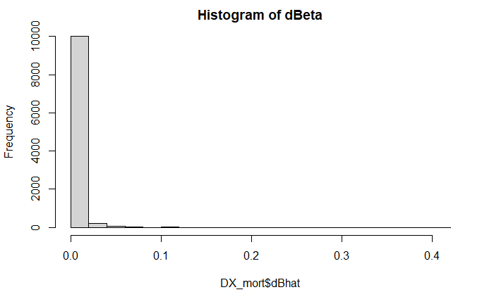

```r
hist(DX_mort$dBhat, main='Histogram of dBeta')
```

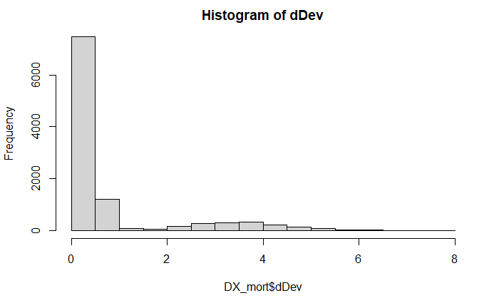

```r
hist(DX_mort$dDev, main='Histogram of dDev')
```

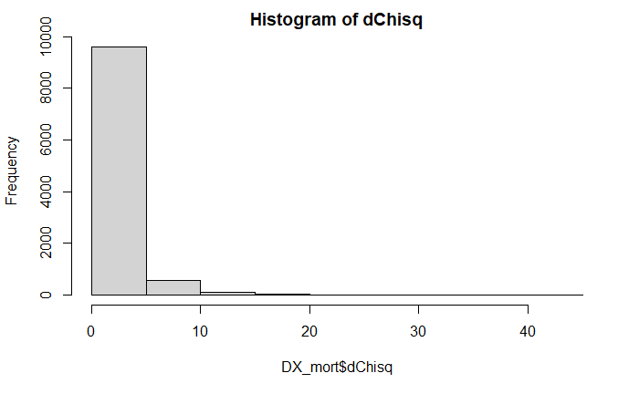

```r
hist(DX_mort$dChisq, main='Histogram of dChisq')
```

### 13.4.3 Residual plots

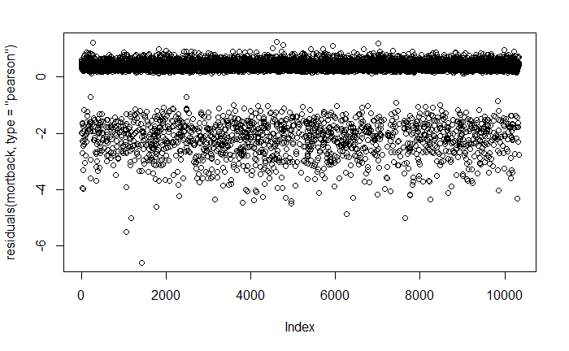

```r
plot(residuals(mortback, type='pearson'))
```

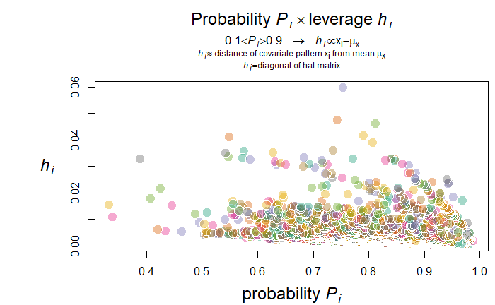

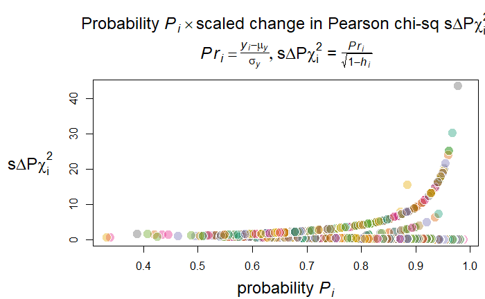

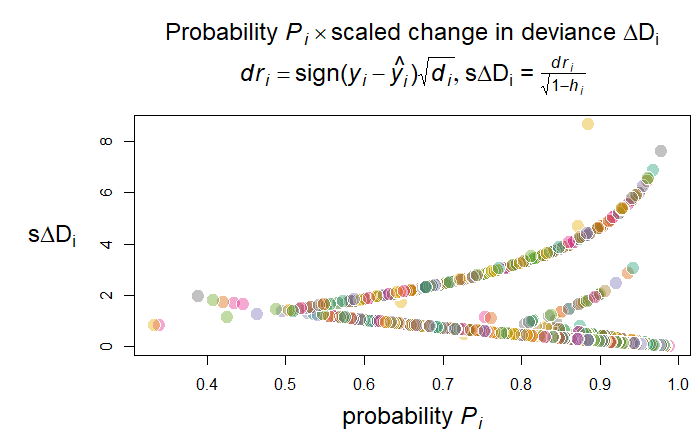

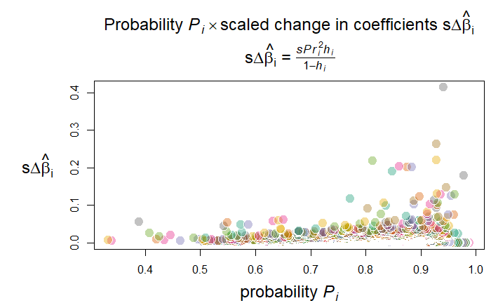

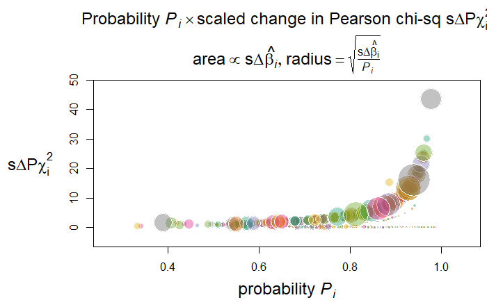

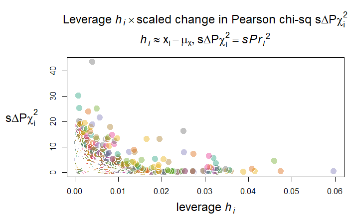

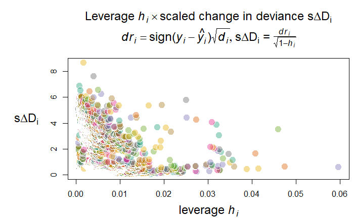

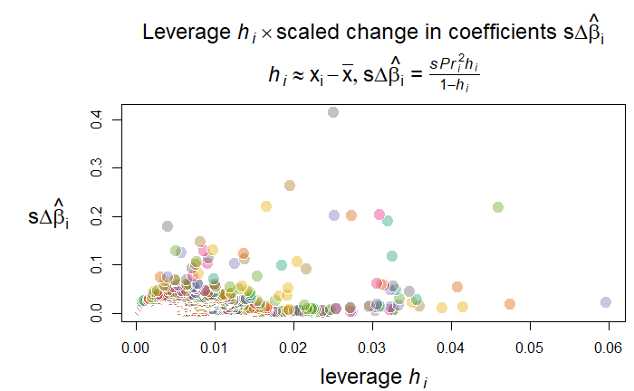

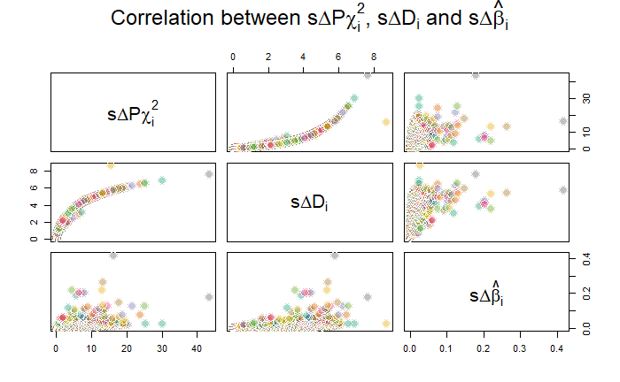

```r
plot(mortback, identify = TRUE, devNew = FALSE)
```

# 14 Coxph Model on Survival Rate

```r
library(survival)
library(hdnom)
```

## 14.1 Model Selection

```r
library(pec)
selectCox(Surv(DX_LASTCONTACT_DEATH_MONTHS,PUF_VITAL_STATUS==0) ~ Chemo
             + AGE_cat
             + SEX
             + RACE2
             + SPANISH_ORIGIN2
             + CROWFLY
             + CDCC_TOTAL_BEST
             + TUMOR_SIZE_cat
             + GRADE
             + Neuroendocrine
             + Visceral_Pleural_Invasion
             + LYMPH_VASCULAR_INVASION2
             + Margins
             + Lymph_Nodes_Sampled
             + Excision_less_than1,
          data=NCDB_lung2, rule = "aic")
```

```
$fit
Cox Proportional Hazards Model

 rms::cph(formula = newform, data = data, surv = TRUE)

                        Model Tests    Discrimination
                                              Indexes
 Obs     10326    LR chi2    459.69    R2       0.047
 Events   1567    d.f.           23    Dxy      0.308
 Center 1.3876    Pr(> chi2) 0.0000    g        0.625
                  Score chi2 466.86    gr       1.867
                  Pr(> chi2) 0.0000

                                   Coef    S.E.   Wald Z Pr(>|Z|)
 Chemo=No Chemo                     0.3112 0.0781  3.98  <0.0001
 AGE_cat=60-70                      0.1563 0.0875  1.79  0.0741
 AGE_cat=70-80                      0.4258 0.0851  5.00  <0.0001
 AGE_cat=Above 80                   0.7156 0.1030  6.95  <0.0001
 AGE_cat=Below 50                  -0.2066 0.2417 -0.85  0.3927
 SEX=Male                           0.4500 0.0520  8.65  <0.0001
 CDCC_TOTAL_BEST                    0.1623 0.0246  6.60  <0.0001
 TUMOR_SIZE_cat=1cm-2cm             0.7876 0.3412  2.31  0.0210
 TUMOR_SIZE_cat=2cm-3cm             0.7428 0.3425  2.17  0.0301
 TUMOR_SIZE_cat=3cm-4cm             1.0150 0.3432  2.96  0.0031
 TUMOR_SIZE_cat=4cm-5cm             1.2164 0.3450  3.53  0.0004
 GRADE=Poorly differentiated        0.2312 0.0561  4.12  <0.0001
 GRADE=Undifferentiated             0.4669 0.1970  2.37  0.0178
 GRADE=Unknown                     -0.1395 0.0962 -1.45  0.1470
 GRADE=Well differentiated         -0.6245 0.1084 -5.76  <0.0001
 Visceral_Pleural_Invasion=Present  0.1654 0.0783  2.11  0.0346
 LYMPH_VASCULAR_INVASION2=Present   0.3009 0.0627  4.80  <0.0001
 LYMPH_VASCULAR_INVASION2=Unknown   0.0091 0.1110  0.08  0.9345
 Margins=Positive                  -0.1281 0.3255 -0.39  0.6940
 Margins=Zero                      -0.5321 0.2933 -1.81  0.0697
 Lymph_Nodes_Sampled=>=10          -0.1375 0.0533 -2.58  0.0099
 Lymph_Nodes_Sampled=Unknown       -0.1134 0.1275 -0.89  0.3737
 Excision_less_than1                0.3206 0.0725  4.42  <0.0001


$In
 [1] "Chemo"                     "AGE_cat"
 [3] "SEX"                       "CDCC_TOTAL_BEST"
 [5] "TUMOR_SIZE_cat"            "GRADE"
 [7] "Visceral_Pleural_Invasion" "LYMPH_VASCULAR_INVASION2"
 [9] "Margins"                   "Lymph_Nodes_Sampled"
[11] "Excision_less_than1"

$call
selectCox(formula = Surv(DX_LASTCONTACT_DEATH_MONTHS, PUF_VITAL_STATUS ==
    0) ~ Chemo + AGE_cat + SEX + RACE2 + SPANISH_ORIGIN2 + CROWFLY +
    CDCC_TOTAL_BEST + TUMOR_SIZE_cat + GRADE + Neuroendocrine +
    Visceral_Pleural_Invasion + LYMPH_VASCULAR_INVASION2 + Margins +
    Lymph_Nodes_Sampled + Excision_less_than1, data = NCDB_lung2,
    rule = "aic")

attr(,"class")
[1] "selectCox"
```

# 15 Backward selection model

```r
library(labelled)
var_label(NCDB_lung2) = list(AGE_cat = 'Age',
               SEX = 'Gender',
               CDCC_TOTAL_BEST = 'Charlson-Deyo Score',
               TUMOR_SIZE_cat = 'Tumor Size',
               GRADE='Grade',
               Margins='Margins',
               LYMPH_VASCULAR_INVASION2 = 'Vascular Invasion',
               Visceral_Pleural_Invasion ='Visceral Pleural Invasion',
               Lymph_Nodes_Sampled = 'Lymph nodes sampled',
               Excision_less_than1='Excision/Resection of <1 lobe ')




NCDB_lung2$Chemo=relevel(as.factor(NCDB_lung2$Chemo), ref="No Chemo" )
cox_fit <- coxph(Surv(DX_LASTCONTACT_DEATH_MONTHS,PUF_VITAL_STATUS) ~ Chemo+
                      AGE_cat+
                      SEX +
                      CDCC_TOTAL_BEST  +
                      TUMOR_SIZE_cat  +
                      GRADE  +
                      Visceral_Pleural_Invasion+
                      LYMPH_VASCULAR_INVASION2+
                      Margins  +
                      Lymph_Nodes_Sampled +
                      Excision_less_than1,
                    data = NCDB_lung2)
summary(cox_fit)
```

```
Call:
coxph(formula = Surv(DX_LASTCONTACT_DEATH_MONTHS, PUF_VITAL_STATUS) ~
    Chemo + AGE_cat + SEX + CDCC_TOTAL_BEST + TUMOR_SIZE_cat +
        GRADE + Visceral_Pleural_Invasion + LYMPH_VASCULAR_INVASION2 +
        Margins + Lymph_Nodes_Sampled + Excision_less_than1,
    data = NCDB_lung2)

  n= 10326, number of events= 8759

                                       coef  exp(coef)   se(coef)      z Pr(>|z|)
ChemoChemo                       -0.0335666  0.9669905  0.0296650 -1.132 0.257835
AGE_cat60-70                     -0.0428041  0.9580991  0.0312749 -1.369 0.171112
AGE_cat70-80                     -0.0324950  0.9680273  0.0316402 -1.027 0.304413
AGE_catAbove 80                  -0.0429432  0.9579658  0.0464323 -0.925 0.355041
AGE_catBelow 50                  -0.0907945  0.9132054  0.0736633 -1.233 0.217740
SEXMale                          -0.0512098  0.9500793  0.0218617 -2.342 0.019158
CDCC_TOTAL_BEST                   0.0039671  1.0039750  0.0116876  0.339 0.734284
TUMOR_SIZE_cat1cm-2cm            -0.0836132  0.9197869  0.0911401 -0.917 0.358926
TUMOR_SIZE_cat2cm-3cm            -0.1176817  0.8889790  0.0919553 -1.280 0.200626
TUMOR_SIZE_cat3cm-4cm            -0.0795032  0.9235750  0.0937480 -0.848 0.396409
TUMOR_SIZE_cat4cm-5cm            -0.0783852  0.9246082  0.0952182 -0.823 0.410385
GRADEPoorly differentiated       -0.0004333  0.9995668  0.0252972 -0.017 0.986333
GRADEUndifferentiated             0.0914740  1.0957883  0.1025315  0.892 0.372310
GRADEUnknown                      0.0042627  1.0042718  0.0381698  0.112 0.911079
GRADEWell differentiated         -0.0502919  0.9509518  0.0339327 -1.482 0.138311
Visceral_Pleural_InvasionPresent  0.0573275  1.0590026  0.0362538  1.581 0.113813
LYMPH_VASCULAR_INVASION2Present  -0.0233576  0.9769131  0.0300918 -0.776 0.437624
LYMPH_VASCULAR_INVASION2Unknown  -0.1405380  0.8688907  0.0465648 -3.018 0.002544
MarginsPositive                   0.0584724  1.0602158  0.1968422  0.297 0.766427
MarginsZero                       0.1816569  1.1992027  0.1782069  1.019 0.308032
Lymph_Nodes_Sampled>=10           0.0523271  1.0537203  0.0224501  2.331 0.019763
Lymph_Nodes_SampledUnknown       -0.2225140  0.8005038  0.0590225 -3.770 0.000163
Excision_less_than1TRUE          -0.0199353  0.9802621  0.0344931 -0.578 0.563298

ChemoChemo
AGE_cat60-70
AGE_cat70-80
AGE_catAbove 80
AGE_catBelow 50
SEXMale                          *
```

[output cut: 34 more lines]

```
GRADEUnknown                        1.0043     0.9957    0.9319    1.0823
GRADEWell differentiated            0.9510     1.0516    0.8898    1.0163
Visceral_Pleural_InvasionPresent    1.0590     0.9443    0.9864    1.1370
LYMPH_VASCULAR_INVASION2Present     0.9769     1.0236    0.9210    1.0363
LYMPH_VASCULAR_INVASION2Unknown     0.8689     1.1509    0.7931    0.9519
MarginsPositive                     1.0602     0.9432    0.7208    1.5594
MarginsZero                         1.1992     0.8339    0.8457    1.7005
Lymph_Nodes_Sampled>=10             1.0537     0.9490    1.0084    1.1011
Lymph_Nodes_SampledUnknown          0.8005     1.2492    0.7131    0.8987
Excision_less_than1TRUE             0.9803     1.0201    0.9162    1.0488

Concordance= 0.524  (se = 0.004 )
Likelihood ratio test= 59.64  on 23 df,   p=4e-05
Wald test            = 57.46  on 23 df,   p=9e-05
Score (logrank) test = 57.61  on 23 df,   p=8e-05
```

## 15.1 Table 2 Adjust

```r
include_columns3 = c('DX_LASTCONTACT_DEATH_MONTHS',
                     'PUF_VITAL_STATUS',
                     'Chemo' ,
                     'AGE',
                     'AGE_cat' ,
                     'SEX' ,
                     'CDCC_TOTAL_BEST',
                     'TUMOR_SIZE_cat',
                     'GRADE',
                     'Pathology',
                     'Visceral_Pleural_Invasion',
                     'LYMPH_VASCULAR_INVASION2',
                     'Margins',
                     'Lymph_Nodes_Sampled',
                     'Excision_less_than1')

relabel_columns3=list(AGE_cat ~ 'Age',
                     SEX ~ 'Gender',
                     CDCC_TOTAL_BEST ~ 'Charlson-Deyo Score',
                     TUMOR_SIZE_cat ~ 'Tumor Size',
                     GRADE~'Grade',
                     LYMPH_VASCULAR_INVASION2 ~ 'Vascular Invasion',
                     Visceral_Pleural_Invasion~'Visceral Pleural Invasion',
                     Lymph_Nodes_Sampled ~ 'Lymph nodes sampled',
                     Excision_less_than1='Excision/Resection of <1 lobe ')

tbl_uvsurv <-
  NCDB_lung[, include_columns3] %>%
  tbl_uvregression(
    method = coxph,
    y = Surv(DX_LASTCONTACT_DEATH_MONTHS,PUF_VITAL_STATUS==1),
    exponentiate = TRUE,
    label=relabel_columns3
  )%>%
  modify_header(
    update = list(
      estimate ~ "**HR**"
    )) %>%  modify_footnote(
    update = estimate ~
      "HR=Hazard Ratio"
  )

tbl_surv <- cox_fit %>% tbl_regression(exponentiate = TRUE,label=relabel_columns3
                                       )%>%
  modify_header(
    update = list(
      estimate ~ "**HR**"
    )) %>%  modify_footnote(
    update = estimate ~
      "HR=Hazard Ratio"
  )

table2_merge <- tbl_merge(
  list(tbl_uvsurv, tbl_surv),
  tab_spanner = c("**Univariate analysis**", "**Multivariable analysis**"))

table2_merge%>%as_flex_table()%>%flextable::save_as_docx(., path = "table2_merge.docx")
table2_merge
```

[output not shown]

<sup>1</sup> HR=Hazard Ratio  
<sup>2</sup> HR = Hazard Ratio, CI = Confidence Interval

```r
#write final data : best predictors of mortality
lung_final=NCDB_lung[, include_columns3]
write.csv(lung_final,"lung_data2.csv", row.names = F)
```

# 16 Forest plot

Next determine the potential benefit received **with the addition of chemotherapy** for **each of the high risk features** listed above.

This may be done by comparing patients with high risk features to those with low risk (no high risk features) and performing a **forest plot** similar to that in Nelson paper, but will also need the HRs for any significant factors.

Factors: - Chemo - High-risk - Interaction term

[figure not shown]

```r
library(jtools)
#plot_survival=plot_summs(cox_fit, exp=TRUE, colors = 'black')


library(survminer)
ggforest(cox_fit)
```

```r
jpeg("cph_forest.jpeg",res=300)
ggforest(cox_fit,main="")+scale_x_discrete(labels=c("AGE_cat"="Age"))
dev.off()
```

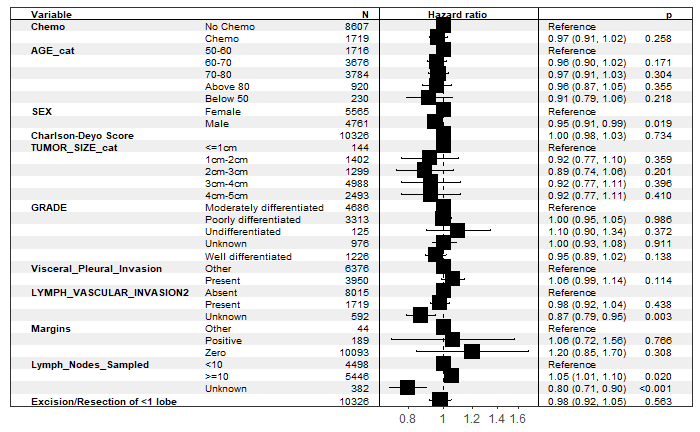

```r
library(forestmodel)
forest_model(cox_fit)
```

```r
library(forestplot)
library(tidyverse)
df <- broom::tidy(cox_fit,  exponentiate = TRUE, conf.int=TRUE)
# pick up estimates and interval
df1 <- df %>%
  transmute(
    HR = round(estimate, 2),
    low = conf.low,
    high = conf.high)
```

```r
# library(ggplot2)
# plot_survival + labs(x = "\n Model-based Hazard Ratio Estimates \n ", y = NULL)
```

```r
# svg("forest.svg", width=7, height=15)
# plot_survival + labs(x = "\n Model-based Hazard Ratio Estimates \n ", y = NULL)
# dev.off()
```

# 17 Nomogram

Develop a **nomogram** based **on these high risk features** to calculate a % risk reduction with the addition of chemotherapy for patients with these high risk features.

- Data: High-risk
- Response Variable: Vita
- Factor: Chemotherapy

```r
library(rms)
units(NCDB_lung2$DX_LASTCONTACT_DEATH_MONTHS) <- "month"
ddist <- datadist(NCDB_lung2[,include_columns3])
options(datadist='ddist')
cph_fit = cph(
  Surv(DX_LASTCONTACT_DEATH_MONTHS, PUF_VITAL_STATUS==0) ~  Chemo*(
                      AGE+
                      SEX +
                      CDCC_TOTAL_BEST  +
                      TUMOR_SIZE_cat  +
                      GRADE  +
                      Pathology +
                      Visceral_Pleural_Invasion+
                      LYMPH_VASCULAR_INVASION2+
                      Margins  +
                      Lymph_Nodes_Sampled +
                      Excision_less_than1),
                    data = NCDB_lung2, surv = TRUE, x=TRUE, y=TRUE, time.inc=24)
surv24=survest(cph_fit)
str(surv24)
```

```
List of 14
 $ n        : int 10326
 $ time     : num [1:1638] 1.05 1.15 1.31 1.38 1.41 1.68 1.71 1.74 1.77 1.81 ...
 $ n.risk   : num [1:1638] 10326 10325 10323 10322 10321 ...
 $ n.event  : num [1:1638] 0 1 1 1 1 3 1 0 1 0 ...
 $ n.censor : num [1:1638] 1 1 0 0 0 0 0 1 0 2 ...
 $ surv     : num [1:1638] 1 1 1 1 1 ...
 $ cumhaz   : num [1:1638] 0 0.000081 0.000162 0.000243 0.000324 ...
 $ std.err  : num [1:1638] 0 0.000081 0.000115 0.00014 0.000162 ...
 $ type     : chr "right"
 $ upper    : num [1:1638] 1 1 1 1 1 ...
 $ lower    : num [1:1638] 1 1 1 0.999 0.999 ...
 $ conf.type: chr "log"
 $ conf.int : num 0.95
 $ call     : language survfit(formula = list(coefficients = c(`Chemo=Chemo` = -1.23974131623754,  AGE = 0.0280139645426426, `SEX=Male` | __truncated__ ...
 - attr(*, "class")= chr [1:3] "survfit.cph" "survfit.cox" "survfit"
```

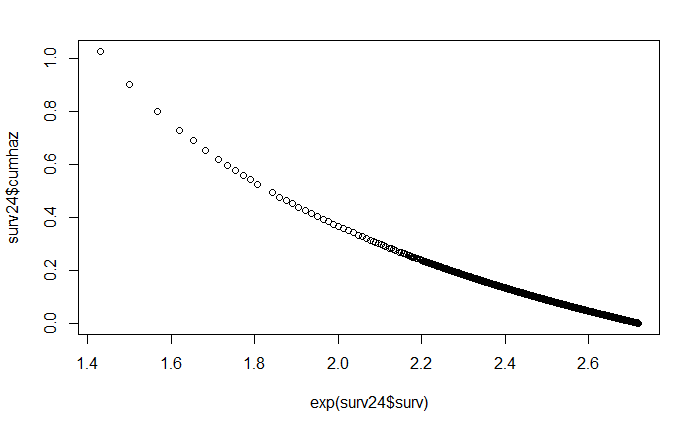

```r
plot(exp(surv24$surv), surv24$cumhaz)
```

```r
cph_fit_chemo = cph(
  Surv(DX_LASTCONTACT_DEATH_MONTHS, PUF_VITAL_STATUS==0) ~
                      AGE+
                      SEX +
                      CDCC_TOTAL_BEST  +
                      TUMOR_SIZE_cat  +
                      GRADE  +
                      Pathology +
                      Visceral_Pleural_Invasion+
                      LYMPH_VASCULAR_INVASION2+
                      Margins  +
                      Lymph_Nodes_Sampled +
                      Excision_less_than1,
                    data = NCDB_lung2, surv = TRUE, x=TRUE, y=TRUE,
  time.inc=24,subset=Chemo=="Chemo")

cph_fit_nochemo = cph(
  Surv(DX_LASTCONTACT_DEATH_MONTHS, PUF_VITAL_STATUS==0) ~
                      AGE+
                      SEX +
                      CDCC_TOTAL_BEST  +
                      TUMOR_SIZE_cat  +
                      GRADE  +
                      Pathology +
                      Visceral_Pleural_Invasion+
                      LYMPH_VASCULAR_INVASION2+
                      Margins  +
                      Lymph_Nodes_Sampled +
                      Excision_less_than1,
                    data = NCDB_lung2, surv = TRUE, x=TRUE, y=TRUE, time.inc=24,subset=Chemo=="No Chemo")


cph_fit3 = cph(
  Surv(DX_LASTCONTACT_DEATH_MONTHS, PUF_VITAL_STATUS==0) ~  Chemo*(
                      AGE+
                      SEX +
                      CDCC_TOTAL_BEST  +
                      TUMOR_SIZE_cat  +
                      GRADE  +
                      Pathology +
                      Visceral_Pleural_Invasion+
                      LYMPH_VASCULAR_INVASION2+
                      Margins  +
                      Lymph_Nodes_Sampled +
                      Excision_less_than1),
                    data = NCDB_lung2, surv = TRUE, x=TRUE, y=TRUE, time.inc=3)



cph_fit60 = cph(
  Surv(DX_LASTCONTACT_DEATH_MONTHS, PUF_VITAL_STATUS==0) ~  Chemo*(
                      AGE+
                      SEX +
                      CDCC_TOTAL_BEST  +
                      TUMOR_SIZE_cat  +
                      GRADE  +
                      Pathology +
                      Visceral_Pleural_Invasion+
                      LYMPH_VASCULAR_INVASION2+
                      Margins  +
                      Lymph_Nodes_Sampled +
                      Excision_less_than1),
                    data = NCDB_lung2, surv = TRUE, x=TRUE, y=TRUE, time.inc=60)
```